# Visualizing the Ten-year Fatal Cardiovascular Risk Modelling among Malaysians using R

Dr. Che Muhammad Nur Hidayat bin Che Nawi

21 November 2020

[figure not shown]

# 1 Motivation

Difficulty in model interpretation.

# 2 Introduction

## 2.1 Cardiovascular Disease

[figure not shown]

We encountered a similar problem with CVD in Malaysia, as it accounted for a quarter of all hospital deaths. The average age at which Malaysians getting CVD is 58.5 years. However, one in four CVD related hospital admissions is those under 50 years of age. This situation is worrying as those age range are the reproductive age group. Thus, it important for us to anticipate the problem by measuring the CVD risk Malaysian and administer early intervention.

[figure not shown]

## 2.2 Globorisk (Hajifathalian et al. (2015))

- It is one of the latest CVD calculator
- It can be specified to each country unlike other CVD calculator. Hence, it is superior compared to previously developed calculator.
- Developed by Public Health team from Harvard University in 2015

## 2.3 Cardiovascular risk

- According to Hajifathalian et al. (2015) and Ueda et al. (2017), the Globorisk calculator has two primary outcomes which are the **fatal Globorisk** risk and **non-fatal Globorisk** risk.
- The fatal Globorisk risk is the probability of having future fatal CVD events in relative to the fatal CVD events in the initial recalibration process for specific country applications

# 3 Objectives

To model the ten year Malaysians CVD risk scores as a function of age adjusted to the ethnicity in Malaysia

# 4 Method

## 4.1 Data source

The 2015 National Health and Morbidity Survey data

## 4.2 Fatal Globorisk stratification (Ueda et al. (2017))

- Low risk as defined as < 10%
- High risk as defined as >= 10%
- High risk as defined as >= 20%
- High risk as defined as >= 30%

## 4.3 Statistical method

- Statitical package used : *ordinal*, *tidyverse*, *haven*, *effects*, *gtsummary*, *forcats*, *dplyr* and *broom*.
- Ordinal logistic regression modeling was used to ascertain the relationship of age category to the ten-year fatal Globorisk score of Malaysians.

### 4.3.1 Cumulative link models (Proportional Odds Models)

- Cumulative link models (CLMs) - *ordinal* package - are an excellent model class for ordinal data as it allows development of flexible regression framework for details analyses.

### 4.3.2 polr

- polr function from MASS package is used in combination with *effects* package to visualize the model through plot.

# 5 Analysis

## 5.1 Preparation for analysis

```r
library(ordinal) #to perform model
library(tidyverse) #data wrangling
library(haven)
library(broom) #to generate more pleasant result
library(gtsummary) #presentation ready table
library(dplyr)
library(forcats) # factor reorder
```

## 5.2 Read data

Under this section, we will perform the following steps: - Convert the data into object and name it as globorisk - Briefly examine the data - Summarize the data

```r
#Read data file form working directory

globorisk <- read.csv("dataRUGgloborisk.csv")

glimpse(globorisk)
```

```
## Rows: 7,660
## Columns: 11
## $ X.1        <int> 1, 2, 3, 4, 5, 6, 7, 8, 9, 10, 11, 12, 13, 14, 15, 16, 1...
## $ X          <int> 1, 2, 3, 4, 5, 6, 7, 8, 9, 10, 11, 12, 13, 14, 15, 16, 1...
## $ state      <chr> "Johor", "Melaka", "Penang", "Perak", "Negeri Sembilan",...
## $ gender     <chr> "Male", "Female", "Male", "Male", "Female", "Male", "Mal...
## $ ethnic     <chr> "Malay", "Malay", "Chinese", "Malay", "Chinese", "Malay"...
## $ agecat     <chr> "80+", "80+", "80+", "80+", "80+", "80+", "80+", "80+", ...
## $ age        <int> 84, 84, 84, 84, 83, 82, 82, 82, 82, 82, 82, 81, 81, 81, ...
## $ region     <chr> "Southern", "Southern", "Northern", "Northern", "Souther...
## $ fatal.cat  <chr> "High 30%", "High 30%", "High 30%", "High 30%", "High 30...
## $ lab.cat    <chr> "High Risk defined as >= 30%", "High Risk defined as >= ...
## $ office.cat <chr> "High Risk defined as >= 30%", "High Risk defined as >= ...
```

Noted that most of the variables are in character form. We will transform the data class into factor.

```r
summary(globorisk)
```

```
##       X.1             X           state              gender
##  Min.   :   1   Min.   :   1   Length:7660        Length:7660
##  1st Qu.:1916   1st Qu.:1916   Class :character   Class :character
##  Median :3830   Median :3830   Mode  :character   Mode  :character
##  Mean   :3830   Mean   :3830
##  3rd Qu.:5745   3rd Qu.:5745
##  Max.   :7660   Max.   :7660
##     ethnic             agecat               age           region
##  Length:7660        Length:7660        Min.   :41.00   Length:7660
##  Class :character   Class :character   1st Qu.:46.00   Class :character
##  Mode  :character   Mode  :character   Median :52.00   Mode  :character
##                                        Mean   :53.42
##                                        3rd Qu.:59.00
##                                        Max.   :84.00
##   fatal.cat           lab.cat           office.cat
##  Length:7660        Length:7660        Length:7660
##  Class :character   Class :character   Class :character
##  Mode  :character   Mode  :character   Mode  :character
##
##
##
```

Summary of the data shows that there is no missing value. If any, the missing value should be dealt accordingly to prevent bias.

We will convert the variables to factors variables

```r
#checking the class of variable within data.frame
str(globorisk)
```

```
## 'data.frame':    7660 obs. of  11 variables:
##  $ X.1       : int  1 2 3 4 5 6 7 8 9 10 ...
##  $ X         : int  1 2 3 4 5 6 7 8 9 10 ...
##  $ state     : chr  "Johor" "Melaka" "Penang" "Perak" ...
##  $ gender    : chr  "Male" "Female" "Male" "Male" ...
##  $ ethnic    : chr  "Malay" "Malay" "Chinese" "Malay" ...
##  $ agecat    : chr  "80+" "80+" "80+" "80+" ...
##  $ age       : int  84 84 84 84 83 82 82 82 82 82 ...
##  $ region    : chr  "Southern" "Southern" "Northern" "Northern" ...
##  $ fatal.cat : chr  "High 30%" "High 30%" "High 30%" "High 30%" ...
##  $ lab.cat   : chr  "High Risk defined as >= 30%" "High Risk defined as >= 30%" "High Risk defined as >= 20%" "High Risk defined as >= 30%" ...
##  $ office.cat: chr  "High Risk defined as >= 30%" "High Risk defined as >= 30%" "High Risk defined as >= 20%" "High Risk defined as >= 30%" ...
```

```r
# converting the dataframe character variables into factor variables and selecting intended variables for analysis

globorisk$ethnic <- as.factor(globorisk$ethnic)
globorisk$agecat <- as.factor(globorisk$agecat)
globorisk$fatal.cat <- as.factor(globorisk$fatal.cat)

globorisk2 <- globorisk %>% select(ethnic, agecat, fatal.cat)

str(globorisk2)
```

```
## 'data.frame':    7660 obs. of  3 variables:
##  $ ethnic   : Factor w/ 5 levels "Chinese","Indian",..: 3 3 1 3 1 3 1 1 3 2 ...
##  $ agecat   : Factor w/ 9 levels "40-44","45-49",..: 9 9 9 9 9 9 9 9 9 9 ...
##  $ fatal.cat: Factor w/ 4 levels "High 10%","High 20%",..: 3 3 3 3 3 3 3 3 3 3 ...
```

The outcome variable is fatal.cat which represent the categorical ten year fatal globorisk risk as mentioned above.

## 5.3 Factor reorder

```r
# Reorder ethnic (Malay as reference group)
globorisk2 <- globorisk2 %>% mutate_at(vars(ethnic), ~fct_relevel(., c("Malay","Chinese",
                                                                       "Indian",
                                                                       "Others Bumis",
                                                                       "Others")))

# Reorder fatal.cat
globorisk2 <- globorisk2 %>% mutate_at(vars(fatal.cat), ~fct_relevel(., c("Low 10%", "High 10%", "High 20%", "High 30%"
                                                                     )))
```

```r
summary(globorisk2)
```

```
##           ethnic         agecat        fatal.cat
##  Malay       :4815   40-44  :1629   Low 10% :5808
##  Chinese     :1352   45-49  :1614   High 10%:1119
##  Indian      : 550   50-54  :1587   High 20%: 406
##  Others Bumis: 618   55-59  :1223   High 30%: 327
##  Others      : 325   60-64  : 820
##                      65-69  : 469
##                      (Other): 318
```

Factor reorder is important to ensure the reference group is meaningful.

## 5.4 Estimation

Next, we will fit the model using *the Proportional Odds Model* or the *Cumulative Link Model*

In ordinal package we can use the function clm to run the maximum likelihood estimates.

Now run the clm() function to estimate:

1. regression coefficients
2. standard errors
3. Wald based p-values (testing the parameters against zero)

```r
globo1 <- clm(fatal.cat ~ agecat + ethnic, data = globorisk2)

summary(globo1)
```

```
## formula: fatal.cat ~ agecat + ethnic
## data:    globorisk2
##
##  link  threshold nobs logLik   AIC     niter max.grad cond.H
##  logit flexible  7660 -4384.05 8798.10 6(0)  3.64e-13 8.3e+02
##
## Coefficients:
##                    Estimate Std. Error z value Pr(>|z|)
## agecat45-49         1.02519    0.17934   5.716 1.09e-08 ***
## agecat50-54         1.95043    0.16633  11.726  < 2e-16 ***
## agecat55-59         2.66922    0.16448  16.228  < 2e-16 ***
## agecat60-64         3.56598    0.16697  21.357  < 2e-16 ***
## agecat65-69         4.96677    0.17691  28.075  < 2e-16 ***
## agecat70-74         6.33084    0.20351  31.108  < 2e-16 ***
## agecat75-79         7.42070    0.28738  25.822  < 2e-16 ***
## agecat80+           8.93345    0.77346  11.550  < 2e-16 ***
## ethnicChinese      -0.71267    0.08718  -8.175 2.97e-16 ***
## ethnicIndian       -0.11877    0.12358  -0.961    0.337
## ethnicOthers Bumis -0.66947    0.13000  -5.150 2.61e-07 ***
## ethnicOthers        0.06291    0.17857   0.352    0.725
## ---
## Signif. codes:  0 '***' 0.001 '**' 0.01 '*' 0.05 '.' 0.1 ' ' 1
##
## Threshold coefficients:
##                   Estimate Std. Error z value
## Low 10%|High 10%    3.4275     0.1532   22.37
## High 10%|High 20%   5.1756     0.1611   32.12
## High 20%|High 30%   6.4499     0.1712   37.67
```

Nice output

```r
tidy(globo1) #from broom package
```

```
## # A tibble: 15 x 6
##    term               estimate std.error statistic   p.value coef.type
##    <chr>                 <dbl>     <dbl>     <dbl>     <dbl> <chr>
##  1 Low 10%|High 10%     3.43      0.153     22.4   7.85e-111 intercept
##  2 High 10%|High 20%    5.18      0.161     32.1   1.94e-226 intercept
##  3 High 20%|High 30%    6.45      0.171     37.7   0.        intercept
##  4 agecat45-49          1.03      0.179      5.72  1.09e-  8 location
##  5 agecat50-54          1.95      0.166     11.7   9.34e- 32 location
##  6 agecat55-59          2.67      0.164     16.2   3.21e- 59 location
##  7 agecat60-64          3.57      0.167     21.4   3.38e-101 location
##  8 agecat65-69          4.97      0.177     28.1   1.97e-173 location
##  9 agecat70-74          6.33      0.204     31.1   1.89e-212 location
## 10 agecat75-79          7.42      0.287     25.8   5.00e-147 location
## 11 agecat80+            8.93      0.773     11.6   7.38e- 31 location
## 12 ethnicChinese       -0.713     0.0872    -8.17  2.97e- 16 location
## 13 ethnicIndian        -0.119     0.124     -0.961 3.37e-  1 location
## 14 ethnicOthers Bumis  -0.669     0.130     -5.15  2.61e-  7 location
## 15 ethnicOthers         0.0629    0.179      0.352 7.25e-  1 location
```

Variable age category is positive in value and the value is increasing with older age. Meanwhile, variable ethnic is in negative value for Chinese, Indian and Others Bumis. This means

```r
tidy(globo1, exponentiate = TRUE, conf.int = TRUE)
```

```
## # A tibble: 15 x 8
##    term      estimate std.error statistic   p.value conf.low conf.high coef.type
##    <chr>        <dbl>     <dbl>     <dbl>     <dbl>    <dbl>     <dbl> <chr>
##  1 Low 10%|~   30.8      0.153     22.4   7.85e-111   NA        NA     intercept
##  2 High 10%~  177.       0.161     32.1   1.94e-226   NA        NA     intercept
##  3 High 20%~  633.       0.171     37.7   0.          NA        NA     intercept
##  4 agecat45~    2.79     0.179      5.72  1.09e-  8    1.98      4.00  location
##  5 agecat50~    7.03     0.166     11.7   9.34e- 32    5.13      9.86  location
##  6 agecat55~   14.4      0.164     16.2   3.21e- 59   10.6      20.2   location
##  7 agecat60~   35.4      0.167     21.4   3.38e-101   25.8      49.7   location
##  8 agecat65~  144.       0.177     28.1   1.97e-173  102.      205.    location
##  9 agecat70~  562.       0.204     31.1   1.89e-212  380.      845.    location
## 10 agecat75~ 1670.       0.287     25.8   5.00e-147  963.     2977.    location
## 11 agecat80+ 7581.       0.773     11.6   7.38e- 31 2035.    49392.    location
## 12 ethnicCh~    0.490    0.0872    -8.17  2.97e- 16    0.413     0.581 location
## 13 ethnicIn~    0.888    0.124     -0.961 3.37e-  1    0.695     1.13  location
## 14 ethnicOt~    0.512    0.130     -5.15  2.61e-  7    0.395     0.658 location
## 15 ethnicOt~    1.06     0.179      0.352 7.25e-  1    0.743     1.50  location
```

After that, we will use tbl_regression function from *gtsummary* package to simplified the model for easier interpretation. The tbl_regression function is highly customizable and allows us to create a presentation ready table.

```r
globo1 %>% tbl_regression(exponentiate = TRUE, label = list(
                            ethnic~"Ethnicity", agecat~"Age Category")) %>%
  modify_header(label = "**Variable**") %>%
  bold_labels()
```

| **Variable** | **exp(Beta)** | **95% CI**<sup>1</sup> | **p-value** |
| --- | --- | --- | --- |
| Low 10%\|High 10% | 30.8 |  | <0.001 |
| High 10%\|High 20% | 177 |  | <0.001 |
| High 20%\|High 30% | 633 |  | <0.001 |
| Age Category |  |  |  |
| 40-44 | — | — |  |
| 45-49 | 2.79 | 1.98, 4.00 | <0.001 |
| 50-54 | 7.03 | 5.13, 9.86 | <0.001 |
| 55-59 | 14.4 | 10.6, 20.2 | <0.001 |
| 60-64 | 35.4 | 25.8, 49.7 | <0.001 |
| 65-69 | 144 | 102, 205 | <0.001 |
| 70-74 | 562 | 380, 845 | <0.001 |
| 75-79 | 1,670 | 963, 2,977 | <0.001 |
| 80+ | 7,581 | 2,035, 49,392 | <0.001 |
| Ethnicity |  |  |  |
| Malay | — | — |  |
| Chinese | 0.49 | 0.41, 0.58 | <0.001 |
| Indian | 0.89 | 0.69, 1.13 | 0.3 |
| Others Bumis | 0.51 | 0.39, 0.66 | <0.001 |
| Others | 1.06 | 0.74, 1.50 | 0.7 |

<sup>*1*</sup> CI = Confidence Interval

# 6 Inferences

Perform inferences by creating new model, and perform comparison with previous model using likelihood ratio test

```r
globo1b <- clm(fatal.cat ~ agecat , data = globorisk2)
anova(globo1b, globo1, test = 'Chisq')
```

```
## 'test' argument ignored in anova.clm
```

```
## Likelihood ratio tests of cumulative link models:
##
##         formula:                    link: threshold:
## globo1b fatal.cat ~ agecat          logit flexible
## globo1  fatal.cat ~ agecat + ethnic logit flexible
##
##         no.par    AIC  logLik LR.stat df Pr(>Chisq)
## globo1b     11 8881.2 -4429.6
## globo1      15 8798.1 -4384.1  91.099  4  < 2.2e-16 ***
## ---
## Signif. codes:  0 '***' 0.001 '**' 0.01 '*' 0.05 '.' 0.1 ' ' 1
```

The comparison can be done by comparing the AIC and looking at the significant of p value.

Taking significant level at 5%, if the p value is less than 0.05 then the two model are significantly different.

# 7 Prediction

To predict the probabilities of *i-th* observation to fall into which outcome category for model with a new data, we need to create a new data first. We will use expand.grid() to create a new data of class data.frame

This is the new data

```r
newData <- expand.grid(agecat= levels(globorisk2$agecat),
                       ethnic= levels(globorisk2$ethnic))

newData
```

```
##    agecat       ethnic
## 1   40-44        Malay
## 2   45-49        Malay
## 3   50-54        Malay
## 4   55-59        Malay
## 5   60-64        Malay
## 6   65-69        Malay
## 7   70-74        Malay
## 8   75-79        Malay
## 9     80+        Malay
## 10  40-44      Chinese
## 11  45-49      Chinese
## 12  50-54      Chinese
## 13  55-59      Chinese
## 14  60-64      Chinese
```

[output cut: 31 more lines]

Now, we will predict the probabilities for a new data. The predicted probabilities are the probabilities that the subject fall into each category of the outcome.

Remember the categories of the outcome are:

```r
levels(globorisk2$fatal.cat)
```

```
## [1] "Low 10%"  "High 10%" "High 20%" "High 30%"
```

We will do the prediction using linear predictor.

```r
lp.newdata <- predict(globo1, newdata = newData, type = 'linear.predictor')
prob.newData <- predict(globo1, newdata = newData, type = 'prob')
lp.newdata ; prob.newData
```

```
## $eta1
##        Low 10%   High 10%    High 20%  High 30%
## 1   3.42745640  5.1756179  6.44991751 100000.00
## 2   2.40226747  4.1504290  5.42472859  99998.97
## 3   1.47702936  3.2251909  4.49949048  99998.05
## 4   0.75823683  2.5063984  3.78069795  99997.33
## 5  -0.13852739  1.6096341  2.88393373  99996.43
## 6  -1.53931371  0.2088478  1.48314741  99995.03
## 7  -2.90338058 -1.1552191  0.11908054  99993.67
## 8  -3.99323888 -2.2450774 -0.97077776  99992.58
## 9  -5.50599035 -3.7578288 -2.48352924  99991.07
## 10  4.14012765  5.8882892  7.16258876 100000.71
## 11  3.11493872  4.8631002  6.13739984  99999.69
## 12  2.18970061  3.9378621  5.21216173  99998.76
## 13  1.47090808  3.2190696  4.49336920  99998.04
```

[output cut: 80 more lines]

```
## $fit
##        Low 10%   High 10%    High 20%     High 30%
## 1  0.968551684 0.02582737 0.004042791 0.0015781580
## 2  0.917000046 0.06748675 0.011126271 0.0043869319
## 3  0.814123464 0.14764786 0.027236192 0.0109924806
## 4  0.680970808 0.24361834 0.053112629 0.0222982177
## 5  0.465423429 0.36793716 0.113685900 0.0529535147
## 6  0.176635063 0.37538794 0.263024508 0.1849524927
## 7  0.051986702 0.18755039 0.290197912 0.4702649945
## 8  0.018106020 0.07766891 0.178950576 0.7252744951
## 9  0.004045927 0.01875634 0.054218666 0.9229790617
## 10 0.984328681 0.01290727 0.001989608 0.0007744453
## 11 0.957504764 0.03482798 0.005511375 0.0021558762
## 12 0.899320802 0.08156195 0.013696905 0.0054203396
## 13 0.813195370 0.14835026 0.027395144 0.0110592286
```

[output cut: 32 more lines]

We can use cbind() to make a better results.

```r
cbind(newData, prob.newData)
```

```
##    agecat       ethnic fit.Low 10% fit.High 10% fit.High 20% fit.High 30%
## 1   40-44        Malay 0.968551684   0.02582737  0.004042791 0.0015781580
## 2   45-49        Malay 0.917000046   0.06748675  0.011126271 0.0043869319
## 3   50-54        Malay 0.814123464   0.14764786  0.027236192 0.0109924806
## 4   55-59        Malay 0.680970808   0.24361834  0.053112629 0.0222982177
## 5   60-64        Malay 0.465423429   0.36793716  0.113685900 0.0529535147
## 6   65-69        Malay 0.176635063   0.37538794  0.263024508 0.1849524927
## 7   70-74        Malay 0.051986702   0.18755039  0.290197912 0.4702649945
## 8   75-79        Malay 0.018106020   0.07766891  0.178950576 0.7252744951
## 9     80+        Malay 0.004045927   0.01875634  0.054218666 0.9229790617
## 10  40-44      Chinese 0.984328681   0.01290727  0.001989608 0.0007744453
## 11  45-49      Chinese 0.957504764   0.03482798  0.005511375 0.0021558762
## 12  50-54      Chinese 0.899320802   0.08156195  0.013696905 0.0054203396
## 13  55-59      Chinese 0.813195370   0.14835026  0.027395144 0.0110592286
## 14  60-64      Chinese 0.639718799   0.27098879  0.062607378 0.0266850307
```

[output cut: 31 more lines]

The prediction allows us to predict the probability of the observations to fall in which outcome category.

Looking at the results: - We can see that any ethnicity at younger age group will fall into low CVD risk group. - While, any ethnicity at older age group will fall into high CVD risk group, in which Malay and Others ethnicity have comparable higher probability to have high CVD risk as compared to other ethnic counter parts. - This prediction is compatible with our model which shows that older age groups have higher odds to have severe CVD risk

For those with visual learner type, looking at this huge amount of number can be trouble some.

Later I will show you on how to visualize the model to make the interpretation easier.

# 8 Checking proportional odds assumption (POS)

The one assumption you have to check is the proportional odds assumption using nominal_test under *ordinal* package.

Let us check if variable ETHNIC (which is a categorical variables) fulfills the proportional odds assumption (POS)

```r
nominal_test(globo1)
```

```
## Tests of nominal effects
##
## formula: fatal.cat ~ agecat + ethnic
##        Df  logLik    AIC    LRT Pr(>Chi)
## <none>    -4384.1 8798.1
## agecat
## ethnic  8 -4376.6 8799.2 14.914  0.06084 .
## ---
## Signif. codes:  0 '***' 0.001 '**' 0.01 '*' 0.05 '.' 0.1 ' ' 1
```

The function test the ordinality of the covariate. In this example, the ethnicity shows that the assumption of proportional odds is presumed (p=0.06).

# 9 Visualizing the Globorisk model

In this section we will use the polr() function form *MASS* package to fit model

Next, we will use Effect() function form *effects* package to plot the model.

## 9.1 Fitting the model

```r
library(MASS)
m_polr <- polr(fatal.cat~agecat+ethnic, data = globorisk2)
summary(m_polr)
```

```
##
## Re-fitting to get Hessian
```

```
## Call:
## polr(formula = fatal.cat ~ agecat + ethnic, data = globorisk2)
##
## Coefficients:
##                       Value Std. Error t value
## agecat45-49         1.02520    0.17934  5.7165
## agecat50-54         1.95043    0.16633 11.7263
## agecat55-59         2.66923    0.16448 16.2278
## agecat60-64         3.56599    0.16697 21.3567
## agecat65-69         4.96678    0.17691 28.0751
## agecat70-74         6.33084    0.20351 31.1077
## agecat75-79         7.42069    0.28738 25.8222
## agecat80+           8.93337    0.77344 11.5503
## ethnicChinese      -0.71267    0.08718 -8.1746
## ethnicIndian       -0.11877    0.12358 -0.9611
## ethnicOthers Bumis -0.66947    0.13000 -5.1498
## ethnicOthers        0.06289    0.17857  0.3522
##
## Intercepts:
##                   Value   Std. Error t value
## Low 10%|High 10%   3.4275  0.1532    22.3692
## High 10%|High 20%  5.1756  0.1611    32.1254
## High 20%|High 30%  6.4499  0.1712    37.6679
##
## Residual Deviance: 8768.104
## AIC: 8798.104
```

## 9.2 Plotting the model

```r
library(effects)
```

```
##
## Re-fitting to get Hessian
```

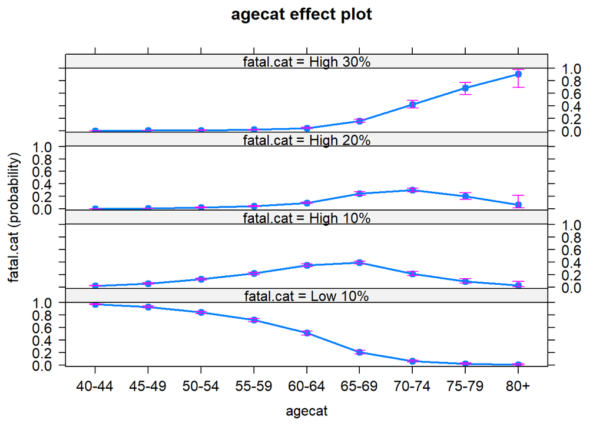

```r
#effect of age category
plot(Effect(focal.predictors = "agecat", m_polr))
```

```
##
## Re-fitting to get Hessian
```

[figure not shown]

```r
#combine effect gender and age category
plot(Effect(focal.predictors = c("agecat", "ethnic"), m_polr))
```

On the effect of **age category**, older age is associated with higher risk of having high CVD risk of >=30%.

When combine between the effect of **age category and ethnic**, all ethnics have high risk of getting high CVD risk at older age group.

# 10 Conclusion

The model shows that older age groups are associated with severe CVD risk when adjusted with ethnicity.

# 11 Thank you

Email: drchehidayat@student.usm.my

github: https://github.com/drchehidayat/RUG-Conference-2020---Globorisk.git

# References

Hajifathalian, Kaveh, Peter Ueda, Yuan Lu, Mark Woodward, Alireza Ahmadvand, Carlos A Aguilar-Salinas, Fereidoun Azizi, et al. 2015. “A Novel Risk Score to Predict Cardiovascular Disease Risk in National Populations (Globorisk): A Pooled Analysis of Prospective Cohorts and Health Examination Surveys.” *The Lancet Diabetes & Endocrinology* 3 (5): 339–55.

Jagannathan, Ram, Shivani A Patel, Mohammed K Ali, and KM Venkat Narayan. 2019. “Global Updates on Cardiovascular Disease Mortality Trends and Attribution of Traditional Risk Factors.” *Current Diabetes Reports* 19 (7): 44.

Ueda, Peter, Mark Woodward, Yuan Lu, Kaveh Hajifathalian, Rihab Al-Wotayan, Carlos A Aguilar-Salinas, Alireza Ahmadvand, et al. 2017. “Laboratory-Based and Office-Based Risk Scores and Charts to Predict 10-Year Risk of Cardiovascular Disease in 182 Countries: A Pooled Analysis of Prospective Cohorts and Health Surveys.” *The Lancet Diabetes & Endocrinology* 5 (3): 196–213.